# NEPA Decarbonization Technology Analysis: Deliverable 3

NEPA Process Analysis

Published

August 21, 2026

## Executive Summary

This report aims to create the following set of deliverables:

> Data on how many decarbonization technology projects have been categorically excluded vs. have required environmental assessments and environmental impact statements. Broken out by number of projects, generation capacity, and change over time.

For context, Figure 1 summarizes the breakdown of projects by energy type.

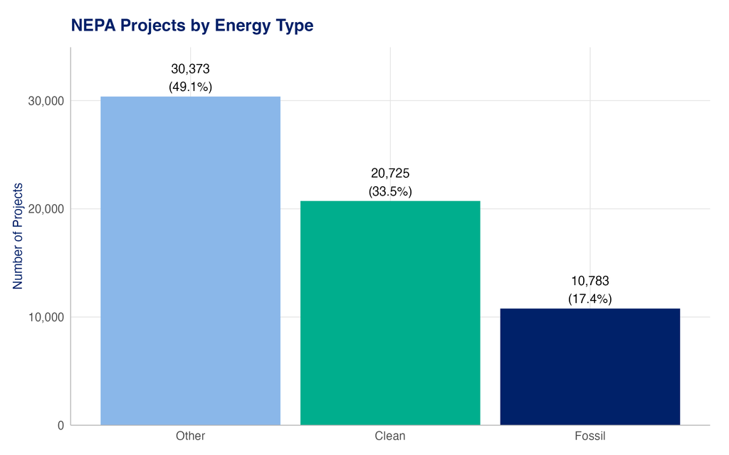

Figure 1: Distribution of all NEPA projects by energy type classification.

# Process Types by Energy Classification

**NoteKey Findings: Process Type**

- **Decarbonization technology projects use Categorical Exclusions at higher rates** than fossil fuel or other types of projects, likely reflecting smaller project footprints.
- **Fossil fuel projects show higher EA/EIS rates**, consistent with larger environmental footprints requiring more detailed review.

Figure 2 visualizes project counts by review and energy type, whereas Figure 3 reports the share of review process types within energy types.

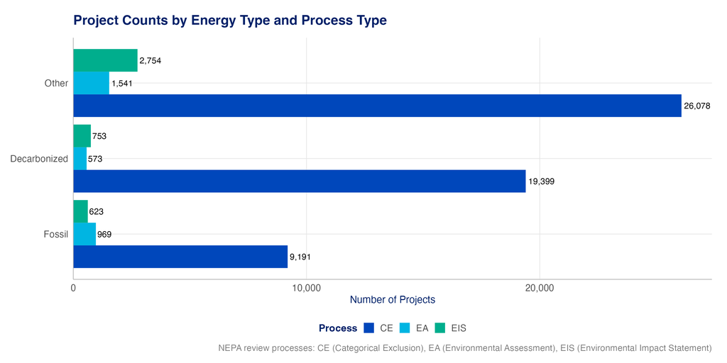

Figure 2: NEPA process type by energy classification

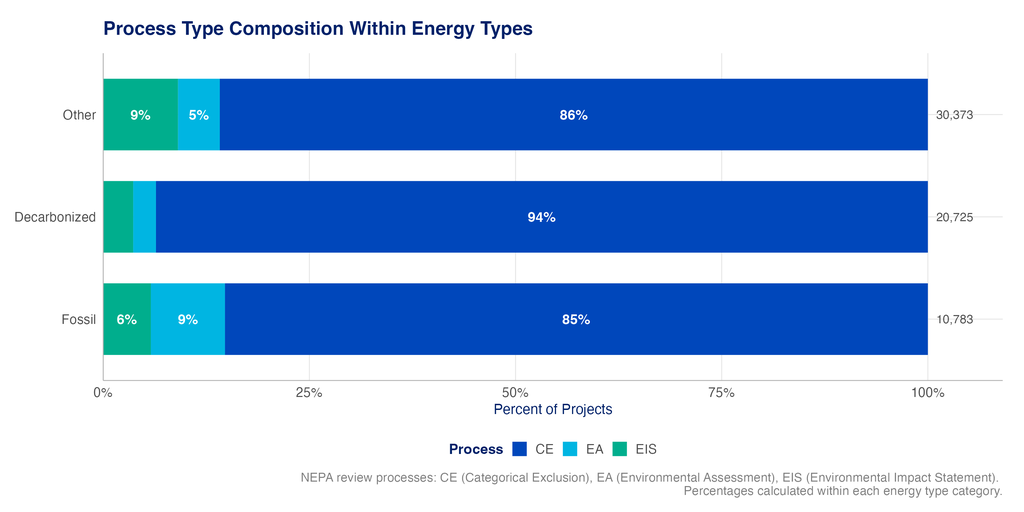

Figure 3: Composition of NEPA process types within each energy classification

# Timeline Analysis for Decarbonization Technologies

**NoteKey Findings: Timeline**

- **CE projects achieve 30% timeline completeness** (both initiation and decision dates), primarily limited by missing initiation dates — many CE documents contain only a single signature date.
- **EA projects are the most complete at 62%**, with the primary gap being missing decision dates.
- **EIS completeness reaches 48%**, constrained mainly by Records of Decision that appear in separate, unlinked documents.
- **Median durations follow expected patterns**: CE ~1 month, EA ~14 months, EIS ~34 months (nearly 3 years), with EIS 90th-percentile reviews exceeding 7.5 years.
- **CE volumes peaked in 2010** (driven by ARRA stimulus funding) and again in 2023; EIS decision peaks lag CE by several years, reflecting longer review cycles.

### How timeline dates are extracted

1. We start with the full text of each NEPA document and look for **dates** in various forms (e.g., “06/07/2018,” “July 7, 2010”, 13 Feb 2010).
2. For each date we capture the surrounding sentence so we can understand **why** that date appears.
3. Then we pass that through a fast classifier (BERT for CE, LLM for EA and EIS) that labels each date into one of four buckets:
   - **Initiation**: when the review appears to start (e.g., “Initiator Signature”, “application received,” or “initiation of consultation”)
   - **Review**: interim steps (e.g., “Phase 1 was approved,” “review completed” or “interim review”)
   - **Decision**: final approval (e.g., “Approved by [Name], NEPA Compliance Officer”, “Authorizing Official”, Field Office Manager determination)
   - **Other**: when it doesn’t fall into one of those three buckets
4. When no explicit initiation date is found, we use the **earliest review date** as a proxy for initiation. A project’s timeline is considered **complete** when both an initiation date and a decision date are available.

### Timeline completeness

Figure 4 shows the share of projects with complete timelines (both initiation and decision dates extracted) by review process. EA projects achieve the highest completeness at 62% (355 of 573), followed by EIS at 48% (362 of 753), and CE at 30% (5,899 of 19,399). The lower CE rate reflects that many CE documents contain only a single signature date with no distinct initiation marker. EIS completeness is limited primarily by missing decision dates, as EIS Records of Decision are often in separate documents that may not be linked in the database.

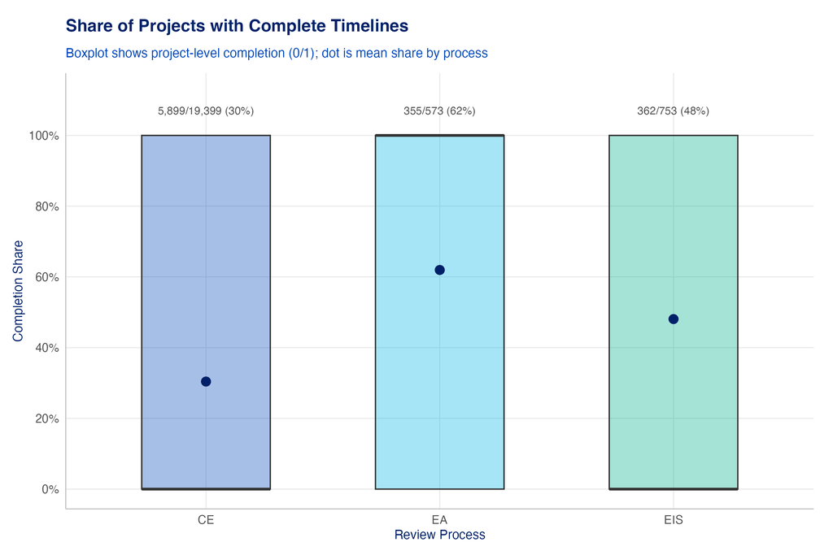

Figure 4: Share of projects with complete timelines by NEPA review process. Dot indicates the mean completion rate.

Figure 5 breaks down the specific gaps in timeline coverage. Each process type shows a distinct pattern of missing data. For CE projects, the largest gap is **missing initiation dates** (~50% of projects), while decision dates are found for the vast majority. EA and EIS projects share a different pattern: the primary gap is **missing decision dates** (~25% for EA, ~31% for EIS), likely because decision language in these longer documents is more varied and Records of Decision may be in separate, unlinked files. EIS projects also have the highest rate of missing both dates (~17%), reflecting that some EIS records in the database lack parseable document text entirely.

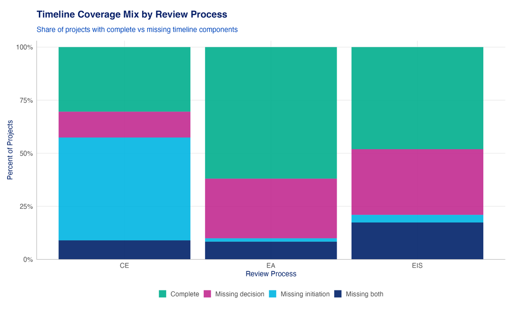

Figure 5: Timeline coverage breakdown by review process, showing which date components are present or missing.

### Duration analysis

Figure 6 compares project durations across all three process types using interval summaries. The progression from CE to EA to EIS tracks the expected complexity of each review level:

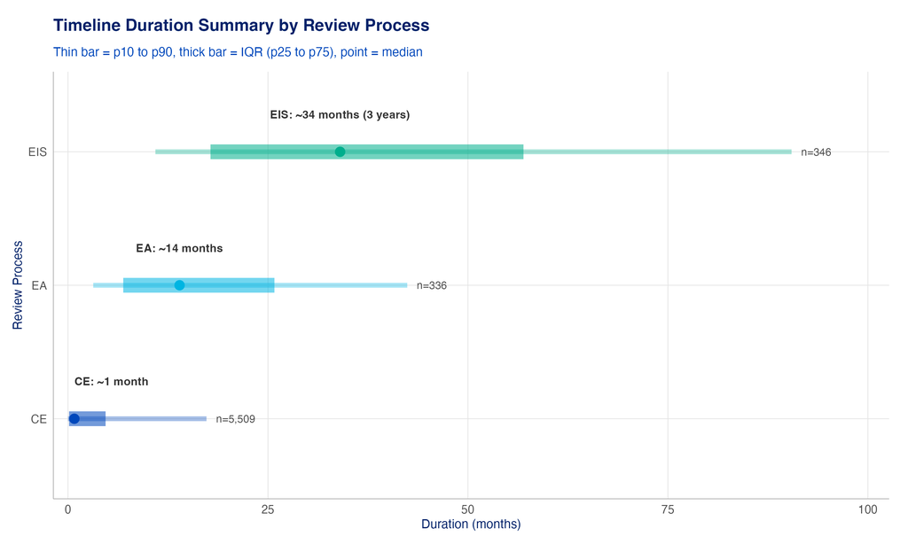

Figure 6: Duration summary by review process. Thin bar spans the 10th to 90th percentile, thick bar shows the interquartile range (25th–75th), and the point marks the median.

Figure 7 visualizes individual project timelines as horizontal segments ordered by duration within each process type. CE timelines are densely clustered from roughly 2008 onward, with most spans appearing as short segments. EA timelines show considerably more variation: shorter projects (green/teal) mix with multi-year reviews (purple/navy), and a handful of projects span 5+ years. EIS timelines are dominated by long-duration reviews — the majority of spans fall in the 2–5 year (purple) and 5+ year (navy) bins, with many projects stretching from the late 2000s through the early 2020s. A few shorter EIS reviews do appear (under 1 year), but these are the exception.

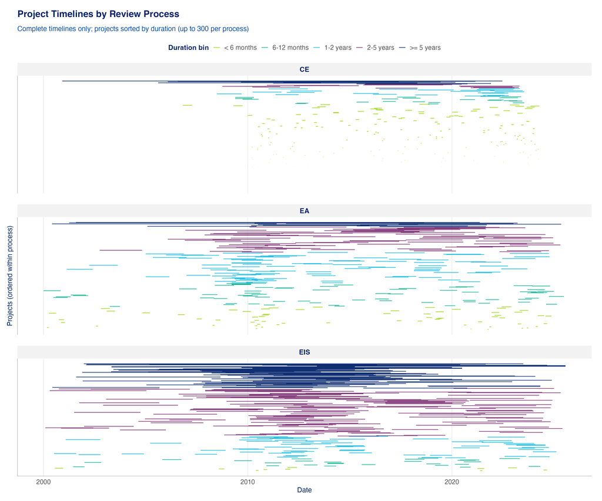

Figure 7: Individual project timelines from initiation to decision, sorted by duration within each process type. Color indicates duration bin. Complete timelines only (up to 300 per process).

### Projects by decision year

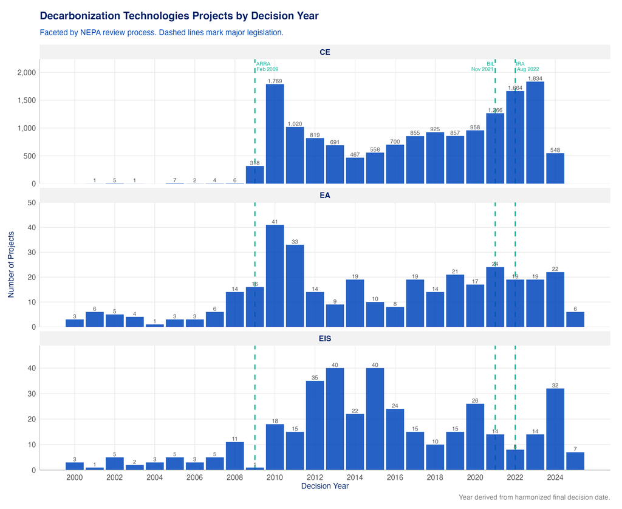

Figure 8: Decarbonization technology projects by decision year, faceted by NEPA review process.

#### DOE projects by decision year

Given the Department of Energy’s (DOE) large share of projects in the NEPATEC 2.0 dataset, one interesting timeline followup question is to look at the distribution of of DOE projects over time. The hypothesis is that DOE’s outsized presence partly reflects NEPA reviews triggered by grant and loan programs created under major decarbonization funding legislation: the American Recovery and Reinvestment Act (ARRA, 2009), the Bipartisan Infrastructure Law (BIL, 2021), and the Inflation Reduction Act (IRA, 2022). To explore this, Figure 9 replicates the decision year chart above but restricted data to DOE projects only (12,727 CE, 233 EA, 101 EIS projects with extractable decision dates).

The DOE-only pattern closely tracks the all-agency pattern, which is expected given DOE’s dominance in the dataset, and closely match the time lag for each of the review processes - the lag between project initiation and final decision averages roughly 1 month for CEs, 1 year for EAs, and 3 years for EIS reviews.

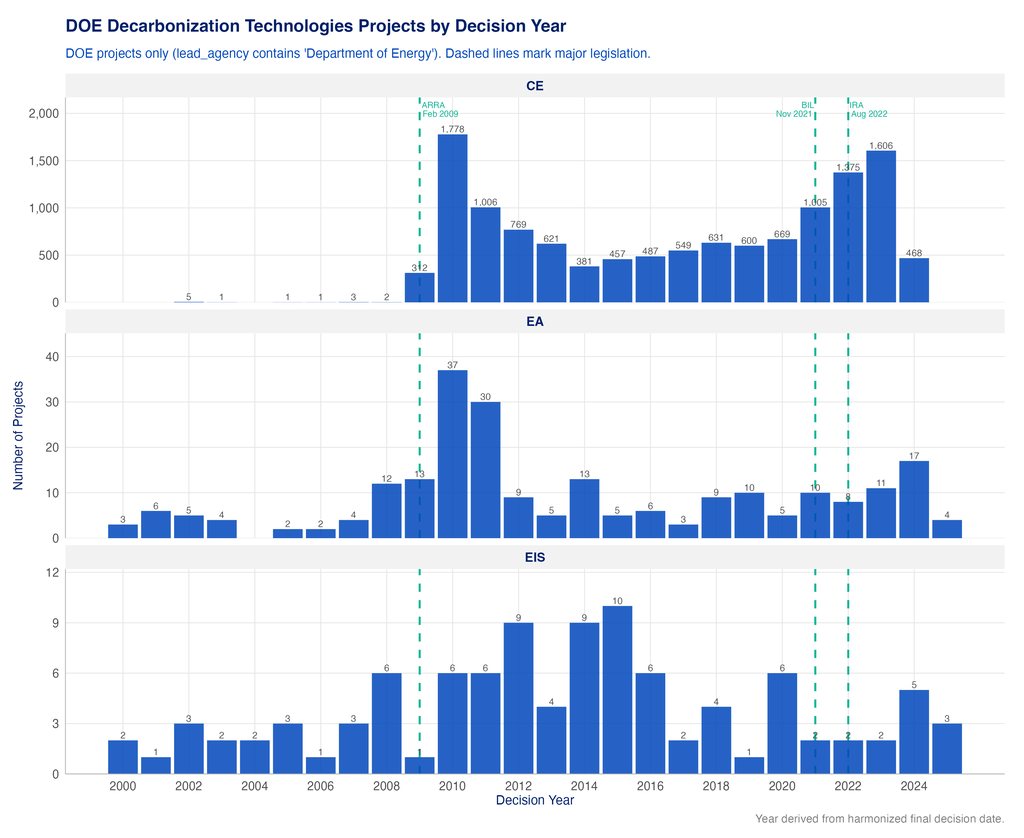

Figure 9: DOE decarbonization technology projects by decision year, faceted by NEPA review process. Only projects where the lead agency is the Department of Energy are included.

### Example Project Timelines

The following examples illustrate the three main situations the classifier encounters across CE projects.

#### Example A: Single decision date only

Table 1: Example A: Single decision date — no timeline possible

**Project:** State and Local Government Partnership

| Type | Date | Source text |
| --- | --- | --- |
| decision | 2010-08-27 | Note to Specialist: Eugene Brown 8/27/2010 SIGNATURE OF THIS MEMORANDUM CONSTITUTES A RECORD OF THIS DECISION. |

**Analysis:** The classifier found only one date in this project’s documents — a decision memorandum signature. While the decision date is correct, there is no initiation or review date to anchor the start of the process.

#### Example B: Multi-phase project with clear decision

Table 2: Example B: Phased project with review milestones and a decision

**Project:** Geothermal Technology Advancement for Rapid Development of Resources in the U.S.

| Type | Date | Source text |
| --- | --- | --- |
| review | 2011-11-30 | one of the technologies by itself. This project includes two phases. Phase 1 was approved by GFO-0005515-001 on Novem... |
| review | 2012-07-16 | energy. gov/GONEPA/EF2a_Form. aspx? key=14050 7/16/2012 Page 2 of 2 NEPA PROVISION DOE has made a final NEPA determin... |
| decision | 2012-07-19 | NEPA Compliance Officer Signature: NEPA Compliance Officer Date: 7/19/2012 |

**Analysis:** This project shows three dates over an 8-month window: two review milestones and a NEPA Compliance Officer signature. The decision date is clear but there’s no initiation date. Phase 1 approval could serve as a reasonable proxy but it’s not 100% clear that it is the initiation date.

#### Example C: Rich timeline with multiple specialists

Table 3: Example C: Multi-specialist sign-off with detailed timeline

**Project:** Right-of-Way Renewals

| Type | Date | Source text |
| --- | --- | --- |
| other | 2020-12-17 | Project Maps PacifiCorp Renewal UTU-65456 Map Created Dec 17, 2020 Cedar City Field Office Color Country BLM |
| other | 2020-12-22 | 4 Miles PacifiCorp Renewal UTU-66885 Map Created Dec 22, 2020 Cedar City Field Office Color Country BLM |
| initiation | 2020-12-31 | This authorization was issued in August of 1990 and is set to expire on December 31, 2020. The renewal would re-autho... |
| decision | 2021-01-05 | Rationale: The proposed authorization would be in conformance with all known environmental laws or requirements under... |
| review | 2021-01-05 | decision in principal about future actions with potentially significant environmental effects. All future actions wou... |
| decision | 2021-01-07 | Initial and Date: D. S. 1/7/21 Erica Shotwell, Rangeland Management Specialist (wetlands, floodplains) |
| decision | 2021-01-11 | is within existing ROWs and has been previously disturbed. Initial and Date: RWP 1/11/2021 David Jacobson, Recreation... |
| review | 2021-01-11 | Rationale: The proposed action would not limit access to any known sites nor affect the physical integrity of such In... |
| decision | 2021-02-04 | E. S. 02/04/2021 2. 3 Would not have highly controversial environmental effects or involve unresolved |
| other | 2021-02-09 | Bureau of Land Management Categorical Exclusion DOI-BLM-UT-C010-2021-0006-CX February 9, 2021 PacifiCorp dba Rocky Mt... |
| decision | 2021-02-09 | Authorizing Official: PAUL BRIGGS Digitally signed by PAUL BRIGGS Date: 2021. 02. 09 09:48:09 -07'00' Date: 2/9/2021 ... |
| initiation | 2021-04-30 | This authorization was issued in May of 1991 and is set to expire on April 30, 2021. The renewal would re-authorize t... |

# Generation Capacity Analysis

### How generation capacity is extracted

The NEPATEC 2.0 metadata does not include generation capacity directly, so we derive it in five major steps:

1. **Metadata-first regex pass**: Scan `project_title` first, then `project_description` variables, for power-capacity expressions (for example, MW/GW/kW values).
2. **Document-page regex pass for unresolved projects**: For projects still missing a value, scan document pages in priority order (main documents first, then other documents).
3. **Candidate + context capture**: Keep up to several power candidates with their local context, along with confidence scoring (high/medium/low) based on whether the surrounding text appears to describe the proposed project.
4. **Targeted LLM adjudication**: Only projects with multiple generation capacity candidates from regex output are sent to Claude. The model receives structured candidates (value, unit, context) and selects the best candidate index.
5. **Final merge**: LLM output is merged back into the same project-level file and used only when it yields a valid power-capacity selection; final fields retain method/source metadata for validation.

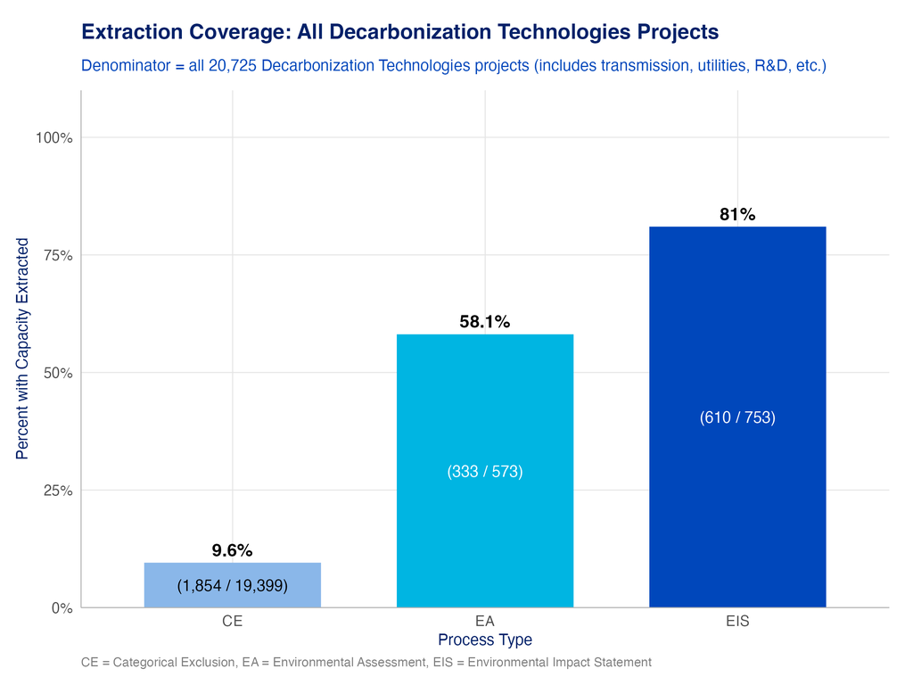

Figure 10: Generation capacity extraction coverage — all decarbonization technology projects (includes transmission, utilities, R&D, etc.)

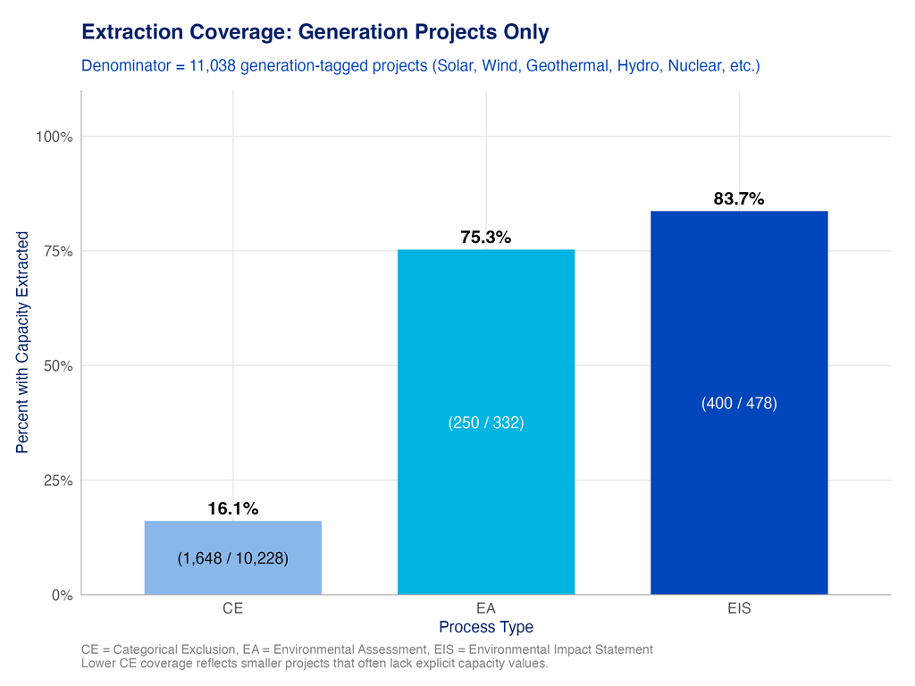

Figure 11: Generation capacity extraction coverage — generation-tagged projects only (Solar, Wind, Geothermal, Hydro, Nuclear, etc.)

The extraction pipeline separately captures **power** (MW/GW/kW — instantaneous generation rate) and **energy** (MWh/GWh/kWh — storage or cumulative output). Figure 12 breaks down coverage for each metric by process type.

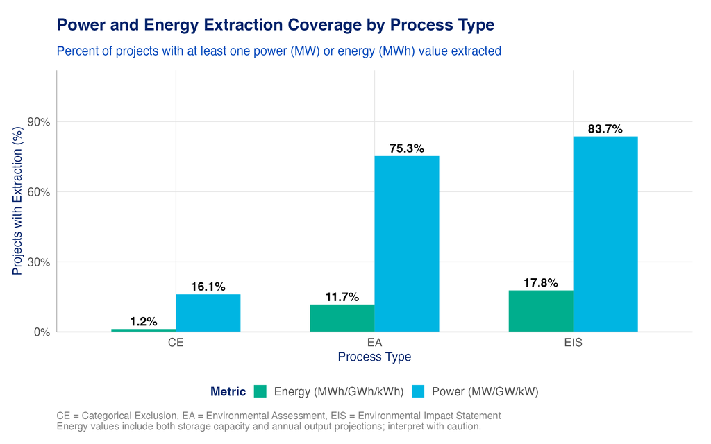

Figure 12: Power vs. energy extraction coverage by process type. Power = instantaneous capacity (MW/GW/kW); Energy = storage or output (MWh/GWh/kWh).

Energy coverage is low overall and is concentrated in EA and EIS projects. The pipeline captures both types, but the **energy values are not used in the capacity bins below** — the MW-based power figures are used for project-size comparisons. Energy captures are most useful for combined solar+storage or standalone battery projects, but the current energy column also picks up annual output projections (e.g., “will generate 800,000 MWh/year”), so values should be interpreted cautiously without further validation.

Figure 13 shows where the capacity value was found for each project. The extraction pipeline checks three sources in order — project title, project description, and document pages — and records which one yielded the first successful match.

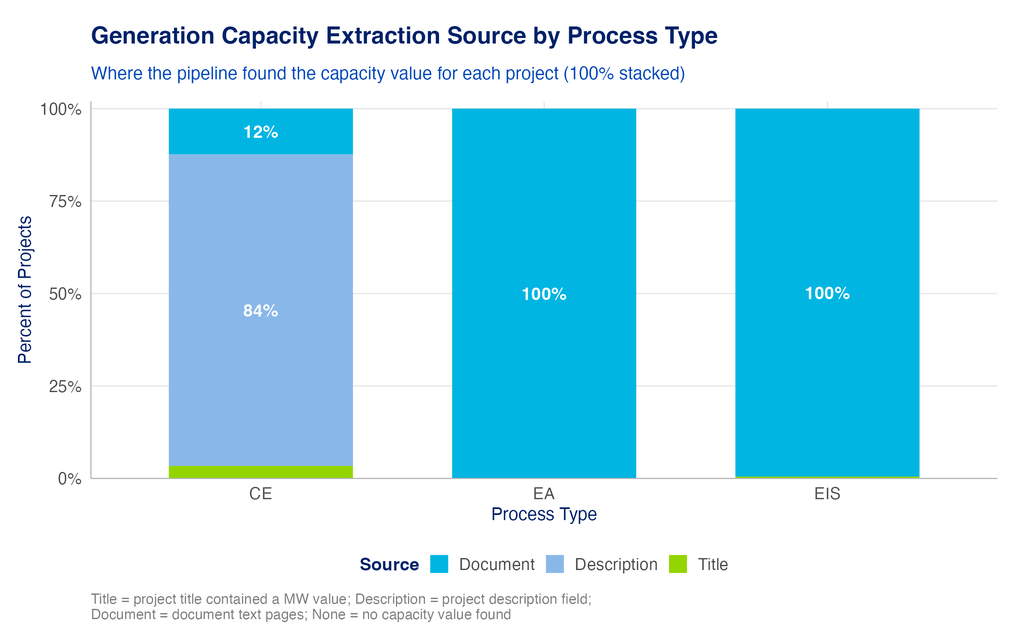

Figure 13: Generation capacity extraction source by process type. Title = capacity found in project title; Description = project description field; Document = document text pages; None = no value found.

Several patterns stand out:

Figure 14 shows the distribution of project sizes across process types. **These figures use power capacity (MW/GW/kW) only** — energy values (MWh/GWh/kWh) are tracked in a separate column and are not included in the size bins. Among projects with extracted capacity:

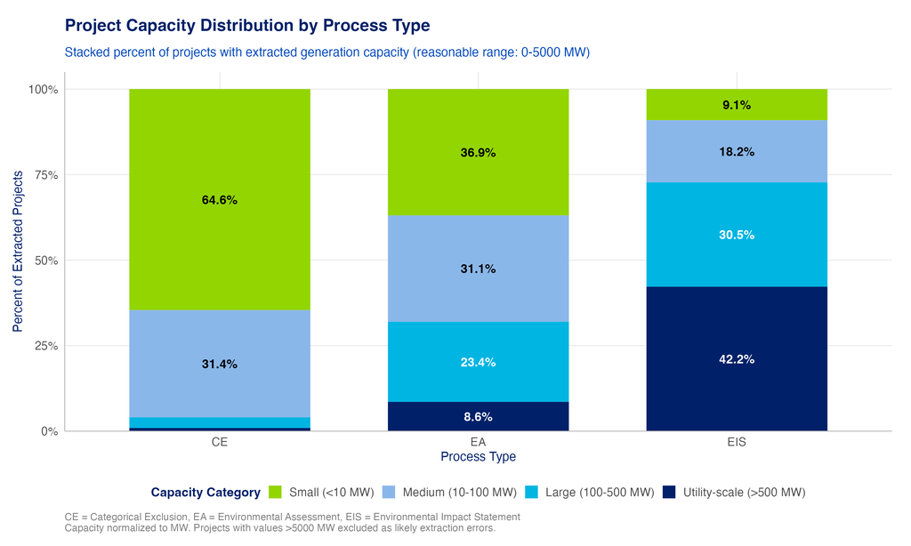

Figure 14: Project capacity distribution by NEPA process type (100% stacked; projects with reasonable extracted values)

Figure 15 shows the full distribution shape of extracted capacities by process type. The violin layer highlights density while the embedded boxplot provides median and interquartile range.

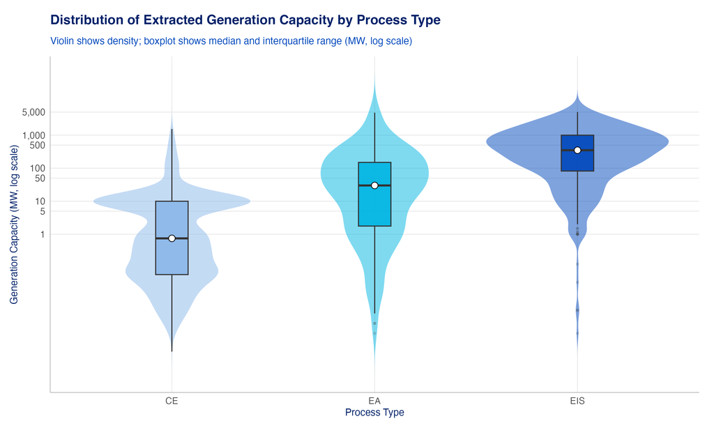

Figure 15: Distribution of extracted generation capacity by process type (violin + boxplot, MW log scale)

### Example Project Extractions

The tables below show a sample of extracted capacity values. The top five rows used regex extraction only (no LLM involvement); the bottom five were adjudicated by the LLM, which overrode the initial regex result. The **Context / Quote** column shows the text window the regex matched (for regex-only projects) or the source sentence cited by the LLM (for LLM-adjudicated projects).

Table 4: Sample capacity extractions: regex-only (top) and LLM-adjudicated (bottom)

| Project Title | Capacity | Context / Quote | LLM Reasoning |
| --- | --- | --- | --- |
| **Regex-only** |  |  |  |
| MSA Annual Categorical Exclusion for Actions to Conserve Energy or Water under 10 CFR 1021, Subpart D, Appendix B, B5.1 for Calendar Year 2017 | 10 MW | changeout); power storage (such as flywheels and batteries, generally less than 10 megawatt equivalent); transportation management systems (such as traffic s... | — |
| Mobile Nuclear Radiation Detection System Test (WFO-DHS) | 25 kW | ure from the ODR test, will add a 28 foot crew trailer to the site as well as a 25 KW portable diesel generator. The MNRDS test will be performed in conjunct... | — |
| New Engineering Concepts to High Energy Density Li-S Batteries | 10 MW | changeout); power storage (such as flywheels and batteries, generally less than 10 megawatt equivalent); transportation management systems (such as traffic s... | — |
| Demonstration and Deployment - Electric Construction Vehicles | 10 MW | changeout); power storage (such as flywheels and batteries, generally less than 10 megawatt equivalent); transportation management systems (such as traffic s... | — |
| The Mid-Atlantic Electrification Partnership: An Electrification Ecosystem of Intermodal Leadership and Intercity Travel | 10 MW | changeout); power storage (such as flywheels and batteries, generally less than 10 megawatt equivalent); transportation management systems (such as traffic s... | — |
| **LLM-adjudicated** |  |  |  |
| Kotzebue Wind Installation Project | 425 kW | 26, and the New World Polar 100. The power ratings for the three turbines are 50 kW, 275 kW, and 100 kW, respectively. Total wind turbine height varies for ... | Three turbines (50kW, 275kW, 100kW) proposed for Kotzebue Wind project; 50kW is per-unit value. |
| Granite Reliable Power Wind Park | 99 MW | enerated by 33 wind driven generators or turbines with a name plate capacity of3.0 megawatts (MW) each, for a total installed 12 IIi | Candidate 5 explicitly states 33 generators × 3.0 MW each for total installed capacity of the proposed project. |
| Proton Improvement Plan-II Project | 1.2 MW | IP-II Project was developed based on the following design criteria: • Deliver 1.2 MW of proton beam power from the Fermilab Main Injector, over the energy ... | Candidate [4] explicitly states PIP-II design criteria to deliver 1.2 MW proton beam power from proposed Main Injector upgrade. |
| Lummi Microgrid Project | 19.2 kW | tion would be followed by a 12 month period of data collection and analysis. A 19.2 kW PV array would be installed on the roof of the aforementioned tribal ... | 19.2 kW PV array is the proposed solar generation capacity for the project. |
| THE NATIONAL COMPACT STELLARATOR EXPERIMENT AT THE PRINCETON PLASMA PHYSICS LABORATORY | 6 MW | east 0.3 seconds). V. Operation at High Confinement and Beta - operation with about 6MW of auxiliary heating and upgraded plasma-facing components (PFCs).... | Describes proposed operation phase with 6MW auxiliary heating for NCSX project |

*Report generated 2026-08-21 | NEPA Decarbonization Technology Analysis*

## Footnotes

[^1]: The full decarbonization technology dataset includes 20,725 projects, but not all are generation facilities. Many are tagged exclusively as Electricity Transmission or Utilities — pole replacements, right-of-way renewals, substation upgrades — as well as R&D, manufacturing, and land management projects that have no electricity generation component. Including these in the denominator artificially deflates coverage rates, since we would never expect them to have a capacity value.